# Examples

Shayan Tohidi

2025-06-18

# Introduction

The `RSD` package provides an open-source and integrated framework for stochastic dominance (SD) (Hadar and Russell 1969), (Hanoch and Levy 1969), (Rothschild and Stiglitz 1970), (Whitmore 1970), and almost stochastic dominance (ASD) (Leshno and Levy 2002), (Tzeng, Huang, and Shih 2013), (Guo et al. 2013) calculations. They can be used for comparing two probability distributions, considering all information included inside the data to address both outcome and risk. The novelties of this package are:

- implementing ASD algorithms, which allows eliminating extreme utilities and performing with more flexibility than SD rules.
- implementing exact algorithms of SD and ASD instead of numerical estimation, which makes the result more accurate, valid, and reliable.

The `RSD` package focuses on providing the most utilized degrees of SD and ASD, meaning the first- and second-order SD and ASD (AFSD and ASSD, respectively). This package has been developed in `R` environment, and can be accessed and downloaded from [CRAN](https://cran.r-project.org/web/packages/RSD/index.html) and [GitHub](https://github.com/ShayanTohidi/RSD.git).

For general information about stochastic dominance, please read (Levy 2015).

# Illustrative Examples

In this section, simple examples are going to be used to explain and understand the concepts and functions’ performance.

## Class

The backbone of the package is the class `StochasticDominance`. Users can create instances directly with `new` command, or call the implemented constructor `createStochasticDominance`. The latter is recommended because it handles all the calculations needed to populate attributes.

### Constructor’s input parameters

The input parameters of the constructor correspond to each probability mass function (PMF).

- `outcome1`, `outcome2`: Numerical vectors, include output values of the corresponding distribution.
- `prob1`, `prob2`: Numerical vectors, include probability values of the corresponding distribution.

### Instance attributes

The process of creating an instance includes combining both PMFs, calculating CDFs, and SSDs.

```r
val1 = c(1,3,5,7)
val2 = c(2,4,6,8)
pr = rep(1/4,4)
sd = createStochasticDominance(val1,val2,pr,pr)
data.frame(outcome = sd@outcome, prob1 = sd@prob1, prob2 = sd@prob2,
           cdf1 = sd@cdf1, cdf2 = sd@cdf2, ssd1 = sd@ssd1, ssd2 = sd@ssd2)
```

```
##   outcome prob1 prob2 cdf1 cdf2 ssd1 ssd2
## 1       1  0.25  0.00 0.25 0.00 0.00 0.00
## 2       2  0.00  0.25 0.25 0.25 0.25 0.00
## 3       3  0.25  0.00 0.50 0.25 0.50 0.25
## 4       4  0.00  0.25 0.50 0.50 1.00 0.50
## 5       5  0.25  0.00 0.75 0.50 1.50 1.00
## 6       6  0.00  0.25 0.75 0.75 2.25 1.50
## 7       7  0.25  0.00 1.00 0.75 3.00 2.25
## 8       8  0.00  0.25 1.00 1.00 4.00 3.00
```

## FSD

Here, we are going to provide two simple example to investigate the FSD rule and corresponding functions of the package.

To get the index of the dominant distribution based on FSD rule, we call `fsd.test` function and pass the object. Also, `fsd.plot` visualizes the CDF values as the step wise functions.

```r
fsd.test(sd)
```

```
## [1] 2
```

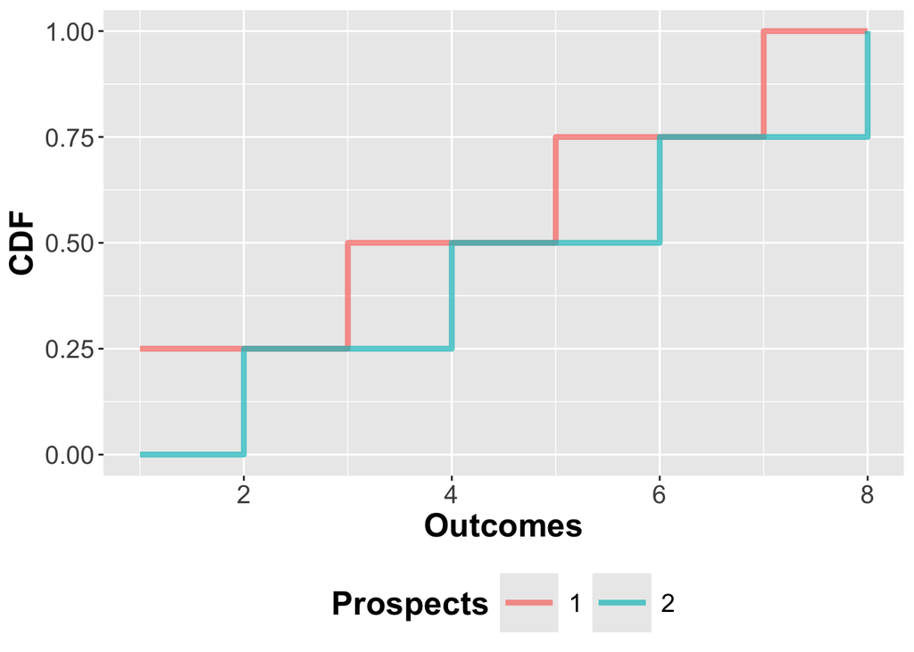

```r
fsd.plot(sd)
```

According to the results, the second distribution dominates the other one by FSD, because the CDF values of the second distribution is always less than or equal than that of the first one. It can be seen from the plot above.

However, it does not happen all the time. Below are an example that there exists no FSD domination.

```r
val1 = c(1,3,5,7,9)
val2 = c(2,4,6,8)
pr1 = rep(1/5,5)
pr2 = rep(1/4,4)
sd = createStochasticDominance(val1,val2,pr1,pr2)
fsd.test(sd)
```

```
## [1] 0
```

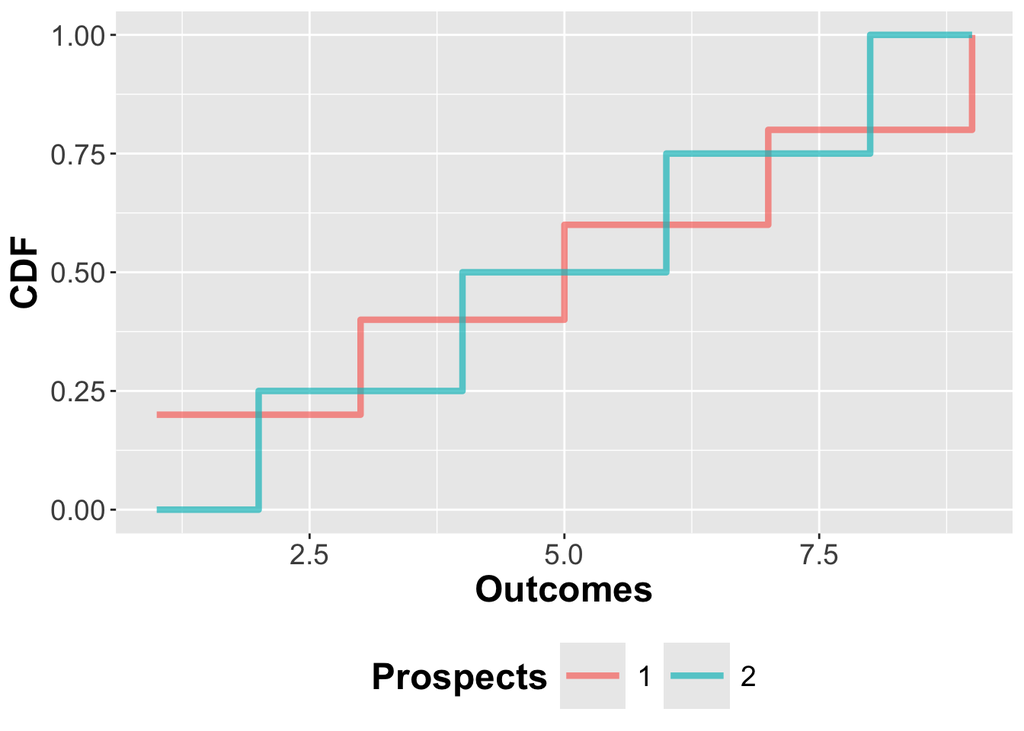

```r
fsd.plot(sd)
```

As seen above, the output value of `fsd.test` function is 0, meaning no domination by any of the distributions based on FSD. According to the plot, the CDFs intersect, which proves no domination.

## SSD

Two examples will be checked here to dive deeper into SSD concept and the `ssd.test` and `ssd.plot` functions.

First, we test the last example from the previous section to check if either distributions dominates the other by SSD.

```r
ssd.test(sd)
```

```
## [1] 2
```

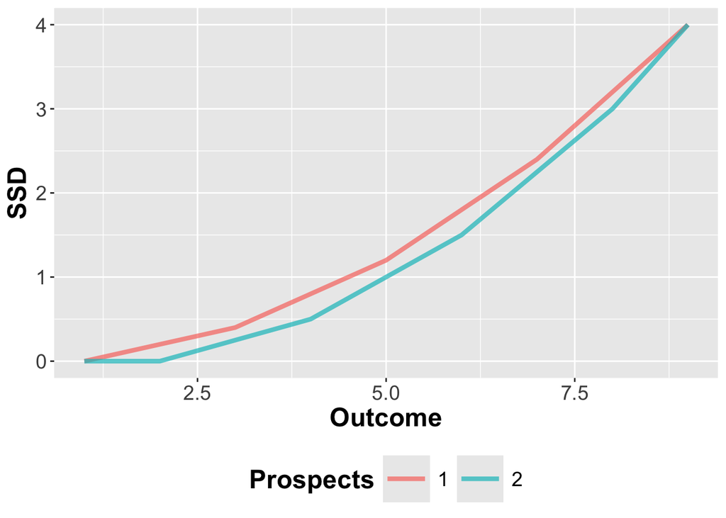

```r
ssd.plot(sd)
```

According to the results, the second distribution dominates the first one by SSD. We can see it from the plot, where the SSD plot corresponding to the second distribution is always lower than or equal to that of the first distribution. Now let’s look at another example.

```r
val1 = c(1,2,5,12)
val2 = c(4,5)
pr1 = rep(1/4,4)
pr2 = rep(1/2,2)
sd = createStochasticDominance(val1,val2,pr1,pr2)
ssd.test(sd)
```

```
## [1] 0
```

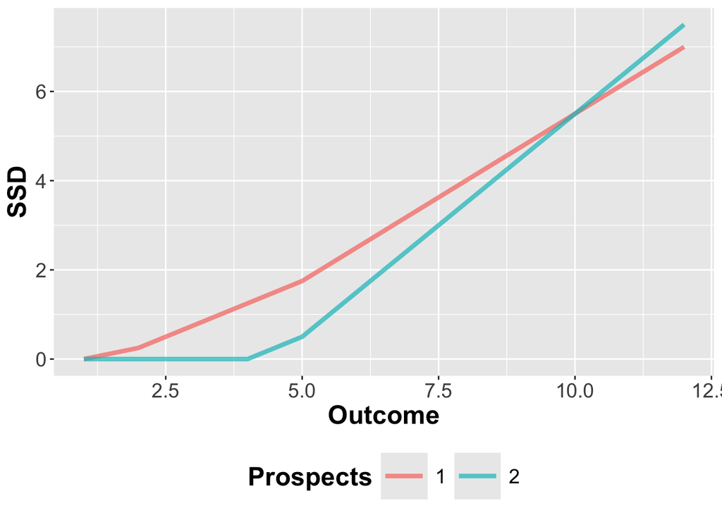

```r
ssd.plot(sd)
```

Because the SSD values intersect, there is no SSD domination, and `ssd.test` returns 0.

## AFSD

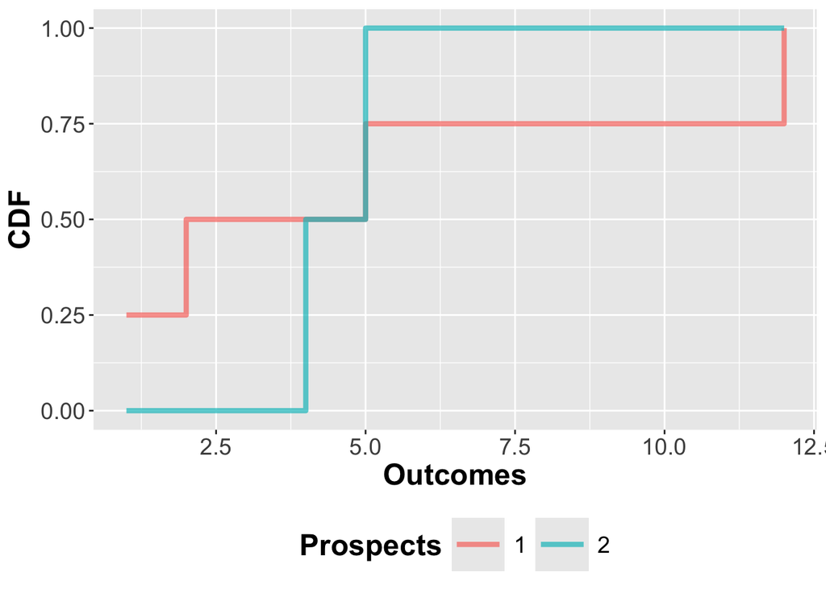

```r
fsd.plot(sd)
```

```r
afsd.test(sd)
```

```
## $winner
## [1] 1
##
## $epsilon
## [1] 0.417
##
## $area
## [1]  0.25  1.00  0.00 -1.75
##
## $total.area
## [1] 3
##
## $positive.area
## [1] 1.25
##
## $negative.area
## [1] 1.75
```

According to the output of `afsd.test` function, the `area` is a numeric vector that shows the area difference corresponding to each segment. So, the area of the first distribution between $1$ and $2$ is $0.25$ larger than that of the second one, and $1.75$ smaller between $5$ and $12$. The `total.area` is the total amount of area surrounded by the CDFs, calculated by adding up the absolute values within the `area` vector. The `total.area` can be divided into two other values: `positive.area` that is the summation of the positive values inside the `area` vector, and `negative.area` that is the summation of the negative values amount. If the CDF of the first distribution is always smaller, all values of the `area` vector would be negative and it dominates the other, so the positive values represent the violation for the first distribution. Based on this, the negative values are the violation of the second distribution. The violation ratio is defined by the violation area (which is `positive.area` and `negative.area`) over `total.area`. The `epsilon` indicates the minimum violation ratio and in this example, it corresponds to the positive area, meaning the first distribution has a smaller violation ratio, and dominates by AFSD. It can also be seen by the `winner`, which shows the dominant index. A condition that should be satisfied is $0<\epsilon<0.5$. If $\epsilon=0$, we have FSD and if $\epsilon=0.5$, the violated areas (`positive.area` and `negative.area`) are equal. This happens if and only if the expected value of two distributions are equal, so the dominant distribution by AFSD (like FSD) always has a higher expected value. In this case, the `winner` would be $0$.

## ASSD

Like the case with AFSD and FSD, when all risk-averse utilities do not agree with a distribution to dominate that is shown by SSD, a decision-maker can use ASSD, which shows what most risk-averse utilities and decision-makers agree. It is achieved by eliminating or ignoring the most extreme utilities. The concept behind ASSD is exactly like AFSD, which is the minimum violation area. However, there are different ways to calculate violation area, and each represents a version of the ASSD. In this package, the version proposed by (Leshno and Levy 2002) is called **LL**, and the one by (Tzeng, Huang, and Shih 2013) is called **THS**. In the **LL** version, the area between CDFs are considered, but the positive and negative areas are determined by both CDF and SSD values. For example, the positive area is where the CDF and SSD values of the first distribution is larger that those of the second one. In the **THS** version, the area between SSDs are considered, and the positive area is where SSD values of the first distribution is larger than that of the second one. Another condition that should be satisfied here is that the dominant distribution should have higher expected value. So, if the `epsilon` of the distribution with higher expected value is larger than $0.5$, there is no domination by ASSD.

```r
assd.test(sd, 'll')
```

[output not shown]

```r
assd.test(sd, 'ths')
```

```
## $winner
## [1] 0
##
## $epsilon
## [1] 0.077
##
## $area
## [1]  0.125  1.500  1.250  3.125 -0.500
##
## $total.area
## [1] 6.5
##
## $positive.area
## [1] 6
##
## $negative.area
## [1] 0.5
```

Here, the `area` is calculated according to the area between SSDs. The `total.area`, `positive.area`, and `negative.area` is calculated in the same way in AFSD. The `epsilon` shows the minimum ratio of `positive.area` or `negative.area` over `total.area`. However, like the other approach, if the expected value of the corresponding distribution is smaller, there will be no dominance. Despite the **LL** version that the $\epsilon$ of both distribution may be smaller than $0.5$, the $\epsilon$ of this **THS** version is smaller than $0.5$ for only one of the distributions.

# Real Examples

There exists a data set in this package, called `data_ex`. It is a real data set extracted from (Fields 2020).

# References

Fields, Genomes to. 2020. “Genomes to Fields 2018 Data Set.” CyVerse Data Commons. https://doi.org/https://doi.org/10.25739/anqq-sg86.

Guo, Xu, Xuehu Zhu, Wing-Keung Wong, and Lixing Zhu. 2013. “A Note on Almost Stochastic Dominance.” *Economics Letters* 121 (2): 252–56. https://doi.org/https://doi.org/10.1016/j.econlet.2013.08.020.

Hadar, Josef, and William R. Russell. 1969. “Rules for Ordering Uncertain Prospects.” *The American Economic Review* 59 (1): 25–34. http://www.jstor.org/stable/1811090.

Hanoch, G., and H. Levy. 1969. “The Efficiency Analysis of Choices Involving Risk.” *The Review of Economic Studies* 36 (3): 335–46. http://www.jstor.org/stable/2296431.

Leshno, Moshe, and Haim Levy. 2002. “Preferred by "All" and Preferred by "Most" Decision Makers: Almost Stochastic Dominance.” *Management Science* 48 (8): 1074–85. http://www.jstor.org/stable/822676.

Levy, Haim. 2015. *Stochastic Dominance: Investment Decision Making Under Uncertainty*. Springer.

Rothschild, Michael, and Joseph E Stiglitz. 1970. “Increasing Risk: I. A Definition.” *Journal of Economic Theory* 2 (3): 225–43. https://doi.org/https://doi.org/10.1016/0022-0531(70)90038-4.

Tzeng, Larry Y., Rachel J. Huang, and Pai-Ta Shih. 2013. “Revisiting Almost Second-Degree Stochastic Dominance.” *Management Science* 59 (5): 1250–54. https://doi.org/10.1287/mnsc.1120.1616.

Whitmore, G. A. 1970. “Third-Degree Stochastic Dominance.” *The American Economic Review* 60 (3): 457–59. http://www.jstor.org/stable/1817999.